# Being Picky About Free Textbooks From Springer

Author

Desmond Choy

Published

April 30, 2020

You might have heard that Springer Nature, an American German academic publishing company, is [giving free access](https://www.springernature.com/gp/librarians/news-events/all-news-articles/industry-news-initiatives/free-access-to-textbooks-for-institutions-affected-by-coronaviru/17855960) to more than 500 key textbooks across Springer Nature’s eBook subject collections, as their way to support lecturers, teachers and students and grant remote access to essential educational resources during this Covid-19 lockdown period. A repository of the books can be [found here](https://link.springer.com/search/page/2?facet-content-type=%22Book%22&package=mat-covid19_textbooks&facet-language=%22En%22&sortOrder=newestFirst&showAll=true).

To my delight, I stumbled across the `springerQuarantineBooksR` package made by [Renan Xavier Cortes](https://github.com/renanxcortes/springerQuarantineBooksR) in a [blog post](https://www.statsandr.com/blog/a-package-to-download-free-springer-books-during-covid-19-quarantine/). After a preliminary scan of the package, I thought this would make for a good opportunity to practise some exploratory data analysis to explore ways to narrow down a search across hundreds of books and their descriptions.

# 1 Import libaries & data

```r
#devtools::install_github("renanxcortes/springerQuarantineBooksR")
library(springerQuarantineBooksR)
library(tidyverse)
theme_set(theme_minimal())
```

# 2 Examining dataset

Once the package is installed, you are now able to download the entire batch of books all at once with this line of code.

```r
#setwd('path_of_your_choice')
#download_springer_book_files()
```

```r
library(skimr)

springer_table <- download_springer_table()
skim(springer_table)
```

Data summary

| Name | springer_table |
| --- | --- |
| Number of rows | 382 |
| Number of columns | 22 |
| _______________________ |  |
| Column type frequency: |  |
| character | 20 |
| logical | 1 |
| numeric | 1 |
| ________________________ |  |
| Group variables | None |

**Variable type: character**

| skim_variable | n_missing | complete_rate | min | max | empty | n_unique | whitespace |
| --- | --- | --- | --- | --- | --- | --- | --- |
| book_title | 0 | 1.00 | 8 | 89 | 0 | 369 | 0 |
| author | 0 | 1.00 | 8 | 115 | 0 | 359 | 0 |
| edition | 0 | 1.00 | 4 | 12 | 0 | 75 | 0 |
| product_type | 0 | 1.00 | 9 | 40 | 0 | 4 | 0 |
| copyright_holder | 0 | 1.00 | 13 | 131 | 0 | 41 | 0 |
| print_isbn | 0 | 1.00 | 17 | 17 | 0 | 382 | 0 |
| electronic_isbn | 0 | 1.00 | 17 | 17 | 0 | 382 | 0 |
| language | 0 | 1.00 | 2 | 2 | 0 | 1 | 0 |
| language_collection | 0 | 1.00 | 21 | 21 | 0 | 1 | 0 |
| e_book_package | 0 | 1.00 | 5 | 5 | 0 | 21 | 0 |
| english_package_name | 0 | 1.00 | 6 | 38 | 0 | 21 | 0 |
| series_print_issn | 203 | 0.47 | 9 | 9 | 0 | 55 | 0 |
| series_electronic_issn | 205 | 0.46 | 9 | 9 | 0 | 53 | 0 |
| series_title | 195 | 0.49 | 6 | 64 | 0 | 62 | 0 |
| volume_number | 358 | 0.06 | 1 | 3 | 0 | 23 | 0 |
| doi_url | 0 | 1.00 | 29 | 40 | 0 | 382 | 0 |
| open_url | 0 | 1.00 | 66 | 66 | 0 | 382 | 0 |
| subject_classification | 0 | 1.00 | 11 | 337 | 0 | 368 | 0 |
| publisher | 0 | 1.00 | 11 | 33 | 0 | 11 | 0 |
| imprint | 0 | 1.00 | 8 | 18 | 0 | 4 | 0 |

**Variable type: logical**

| skim_variable | n_missing | complete_rate | mean | count |
| --- | --- | --- | --- | --- |
| german_package_name | 382 | 0 | NaN | : |

**Variable type: numeric**

| skim_variable | n_missing | complete_rate | mean | sd | p0 | p25 | p50 | p75 | p100 | hist |
| --- | --- | --- | --- | --- | --- | --- | --- | --- | --- | --- |
| copyright_year | 0 | 1 | 2014.7 | 4.4 | 1993 | 2013 | 2016 | 2018 | 2020 | ▁▁▁▃▇ |

I looked around at the Github repo and found this [explanation](https://github.com/renanxcortes/springerQuarantineBooksR/issues/5) by the author:

“Currently, due to the fact that the package works with the book title (in order to facilitate the creation of subgroups of books by title), **It fetches the latest edition of each book. In fact, that’s why the number of books generated is lower than the number of lines of the .xlsx file catalog that springer made available.** Perhaps, it is worth to check an alternative to download all editions of the same book.”

Perusing the column names together with a `head()`+`transmute()` combo, I’ll filter out some columns which doesn’t interest me.

```r
colnames(springer_table)
```

```
 [1] "book_title"             "author"                 "edition"
 [4] "product_type"           "copyright_year"         "copyright_holder"
 [7] "print_isbn"             "electronic_isbn"        "language"
[10] "language_collection"    "e_book_package"         "english_package_name"
[13] "german_package_name"    "series_print_issn"      "series_electronic_issn"
[16] "series_title"           "volume_number"          "doi_url"
[19] "open_url"               "subject_classification" "publisher"
[22] "imprint"
```

```r
t(head(springer_table, 3))
```

```
                       [,1]
book_title             "Fundamentals of Power Electronics"
author                 "Robert W. Erickson, Dragan Maksimovic"
edition                "2nd ed. 2001"
product_type           "Graduate/advanced undergraduate textbook"
copyright_year         "2001"
copyright_holder       "Springer Science+Business Media New York"
print_isbn             "978-0-7923-7270-7"
electronic_isbn        "978-0-306-48048-5"
language               "EN"
language_collection    "English/International"
e_book_package         "11647"
english_package_name   "Engineering"
german_package_name    NA
series_print_issn      NA
series_electronic_issn NA
series_title           NA
volume_number          NA
doi_url                "http://doi.org/10.1007/b100747"
open_url               "http://link.springer.com/openurl?genre=book&isbn=978-0-306-48048-5"
subject_classification "Engineering; Circuits and Systems; Energy, general; Electronics and Microelectronics, Instrumentation; Energy Systems"
publisher              "Springer US"
imprint                "Springer"
                       [,2]
book_title             "Handbook of the Life Course"
author                 "Jeylan T. Mortimer, Michael J. Shanahan"
edition                "2003"
product_type           "Graduate/advanced undergraduate textbook"
copyright_year         "2003"
copyright_holder       "Springer Science+Business Media New York"
print_isbn             "978-0-306-47498-9"
electronic_isbn        "978-0-306-48247-2"
language               "EN"
language_collection    "English/International"
e_book_package         "11648"
english_package_name   "Humanities, Social Sciences and Law"
german_package_name    NA
series_print_issn      "1389-6903"
series_electronic_issn "2542-839X"
series_title           "Handbooks of Sociology and Social Research"
```

[output cut: 14 more lines]

```
electronic_isbn        "978-0-387-21736-9"
language               "EN"
language_collection    "English/International"
e_book_package         "11649"
english_package_name   "Mathematics and Statistics"
german_package_name    NA
series_print_issn      "1431-875X"
series_electronic_issn "2197-4136"
series_title           "Springer Texts in Statistics"
volume_number          NA
doi_url                "http://doi.org/10.1007/978-0-387-21736-9"
open_url               "http://link.springer.com/openurl?genre=book&isbn=978-0-387-21736-9"
subject_classification "Mathematics; Computational Mathematics and Numerical Analysis; Probability Theory and Stochastic Processes; Complex Systems; Statistical Theory and Methods; Probability and Statistics in Computer Science; Statistics for Engineering, Physics, Computer Science, Chemistry and Ea…
publisher              "Springer New York"
imprint                "Springer"
```

```r
springer <- springer_table %>%
  select(1:3, 9, 12, 16:17, 19:21) #selecting columns that I want
```

I want to explore two columns specifically:

- `english_package_name`: General categorisation e.g. Mathematics and Statistics, Engineering, Computer Science, etc.
- `subject_classification`: Specific sub-categories e.g. Linear and Multilinear Algebras, Chemical Engineering, Python, etc.

```r
springer %>%
  count(english_package_name, sort = T)
```

```
# A tibble: 21 × 2
   english_package_name                n
   <chr>                           <int>
 1 Mathematics and Statistics         54
 2 Computer Science                   43
 3 Physics and Astronomy              41
 4 Engineering                        33
 5 Chemistry and Materials Science    31
 6 Biomedical and Life Sciences       28
 7 Business and Management            24
 8 Business and Economics             16
 9 Behavioral Science                 10
10 Energy                             10
# ℹ 11 more rows
```

```r
springer %>%
  count(subject_classification, sort = T)
```

```
# A tibble: 368 × 2
   subject_classification                                                      n
   <chr>                                                                   <int>
 1 Engineering; Circuits and Systems; Processor Architectures; Logic Desi…     6
 2 Mathematics; Analysis                                                       4
 3 Chemistry; Food Science; Industrial Chemistry/Chemical Engineering; Sp…     2
 4 Computer Science; Computer Appl. in Administrative Data Processing; Bu…     2
 5 Engineering; Control; Systems Theory, Control; Computer Applications        2
 6 Mathematics; Linear and Multilinear Algebras, Matrix Theory                 2
 7 Physics; Numerical and Computational Physics, Simulation; Mathematical…     2
 8 Social Sciences; Archaeology                                                2
 9 Biomedicine; Biomedical Engineering/Biotechnology; Biomedical Engineer…     1
10 Biomedicine; Biomedicine, general; Chemistry/Food Science, general; Ph…     1
# ℹ 358 more rows
```

So if one is looking for a book, it’s better to search for sub-categories under `subject_classification`. However, multiple sub-categories are listed under `subject_classification` column per book. I plan to `separate()` then `pivot_longer()` to make our [data tidy](https://cran.r-project.org/web/packages/tidyr/vignettes/tidy-data.html).

```r
springer2 <- springer %>%
  separate(subject_classification, paste("category", 1:8, sep = ""), sep = ";")

springer2 %>%
  select(book_title, english_package_name, contains("cat"))
```

```
# A tibble: 382 × 10
   book_title       english_package_name category1 category2 category3 category4
   <chr>            <chr>                <chr>     <chr>     <chr>     <chr>
 1 Fundamentals of… Engineering          Engineer… " Circui… " Energy… " Electr…
 2 Handbook of the… Humanities, Social … Social S… " Sociol… " Clinic… " Popula…
 3 All of Statisti… Mathematics and Sta… Mathemat… " Comput… " Probab… " Comple…
 4 Social Anxiety … Behavioral Science   Psycholo… " Clinic… " Person… " Commun…
 5 Discrete Mathem… Mathematics and Sta… Mathemat… " Combin… " Number…  <NA>
 6 Developmental N… Biomedical and Life… Biomedic… " Neuros… " Anatom… " Neurob…
 7 Intuitive Proba… Engineering          Engineer… " Commun… " Mathem… " Mathem…
 8 Handbook of Dis… Humanities, Social … Social S… " Sociol… " Public… " Demogr…
 9 Handbook of the… Humanities, Social … Social S… " Sociol… " Social… " Person…
10 Handbook of Soc… Humanities, Social … Social S… " Sociol… " Politi…  <NA>
# ℹ 372 more rows
# ℹ 4 more variables: category5 <chr>, category6 <chr>, category7 <chr>,
#   category8 <chr>
```

```r
skim(springer2)
```

Data summary

| Name | springer2 |
| --- | --- |
| Number of rows | 382 |
| Number of columns | 17 |
| _______________________ |  |
| Column type frequency: |  |
| character | 17 |
| ________________________ |  |
| Group variables | None |

**Variable type: character**

| skim_variable | n_missing | complete_rate | min | max | empty | n_unique | whitespace |
| --- | --- | --- | --- | --- | --- | --- | --- |
| book_title | 0 | 1.00 | 8 | 89 | 0 | 369 | 0 |
| author | 0 | 1.00 | 8 | 115 | 0 | 359 | 0 |
| edition | 0 | 1.00 | 4 | 12 | 0 | 75 | 0 |
| language | 0 | 1.00 | 2 | 2 | 0 | 1 | 0 |
| english_package_name | 0 | 1.00 | 6 | 38 | 0 | 21 | 0 |
| series_title | 195 | 0.49 | 6 | 64 | 0 | 62 | 0 |
| volume_number | 358 | 0.06 | 1 | 3 | 0 | 23 | 0 |
| open_url | 0 | 1.00 | 66 | 66 | 0 | 382 | 0 |
| category1 | 0 | 1.00 | 3 | 32 | 0 | 25 | 0 |
| category2 | 2 | 0.99 | 5 | 65 | 0 | 201 | 0 |
| category3 | 32 | 0.92 | 7 | 88 | 0 | 226 | 0 |
| category4 | 81 | 0.79 | 8 | 85 | 0 | 206 | 0 |
| category5 | 188 | 0.51 | 6 | 88 | 0 | 152 | 0 |
| category6 | 288 | 0.25 | 9 | 56 | 0 | 88 | 0 |
| category7 | 345 | 0.10 | 11 | 84 | 0 | 36 | 0 |
| category8 | 382 | 0.00 | NA | NA | 0 | 0 | 0 |
| publisher | 0 | 1.00 | 11 | 33 | 0 | 11 | 0 |

Another way to scan for missing values would be using the `map_df()` function by the purrr package. Once again we obtain the same outcome.

```r
springer2 %>%
  select(contains("cat")) %>%
  map_df(~sum(is.na(.)))
```

```
# A tibble: 1 × 8
  category1 category2 category3 category4 category5 category6 category7
      <int>     <int>     <int>     <int>     <int>     <int>     <int>
1         0         2        32        81       188       288       345
# ℹ 1 more variable: category8 <int>
```

## 2.1 Data visualization

I’ll proceed to remove that column, followed by making our data long with `pivot_longer()` so that we can process it later.

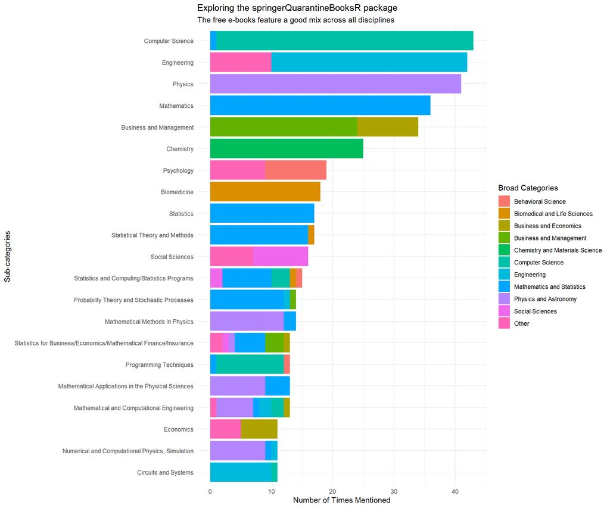

```r
springer_tidy <- springer2 %>%
  select(-category8) %>%
  pivot_longer(
    9:15,
    names_to = "cat",
    values_to = "categories",
    values_drop_na = T
  )

springer_tidy %>%
  select(book_title, english_package_name, categories) %>%
  add_count(categories) %>%
  filter(n > 10) %>%
  ggplot(aes(fct_reorder(categories, n), n/n, fill = fct_lump_n(english_package_name, 10))) +
  geom_col() +
  coord_flip() +
  labs(
    title = "Exploring the springerQuarantineBooksR package",
    subtitle = "The free e-books feature a good mix across all disciplines",
    fill = "Broad Categories",
    x = "Sub-categories",
    y = "Number of Times Mentioned"
  )
```

Some observations:

- Physics, Mathematics, Chemistry and Statistics are very straightforward categories - you won’t be surprised
- Categories like Mathematical & Computer Engineering and Statistics & Computing, on the other hand, are inter-disciplinary.

To narrow down potentially interesting sub-categories, I created word clouds to highlight the most popular ones, in the event anyone is looking for inspiration on topics to dive into.

# 3 Data visualization: Word clouds

```r
springer_tidy %>% count(categories, , sort = TRUE)
```

```
# A tibble: 540 × 2
   categories                            n
   <chr>                             <int>
 1 "Computer Science"                   43
 2 "Engineering"                        42
 3 "Physics"                            41
 4 "Mathematics"                        36
 5 "Business and Management"            34
 6 "Chemistry"                          25
 7 "Psychology"                         19
 8 "Biomedicine"                        18
 9 " Statistical Theory and Methods"    17
10 "Statistics"                         17
# ℹ 530 more rows
```

```r
springer_tidy %>% distinct(categories)
```

```
# A tibble: 540 × 1
   categories
   <chr>
 1 "Engineering"
 2 " Circuits and Systems"
 3 " Energy, general"
 4 " Electronics and Microelectronics, Instrumentation"
 5 " Energy Systems"
 6 "Social Sciences"
 7 " Sociology, general"
 8 " Clinical Psychology"
 9 " Population Economics"
10 "Mathematics"
# ℹ 530 more rows
```

```r
springer_tidy %>% distinct(english_package_name)
```

```
# A tibble: 21 × 1
   english_package_name
   <chr>
 1 Engineering
 2 Humanities, Social Sciences and Law
 3 Mathematics and Statistics
 4 Behavioral Science
 5 Biomedical and Life Sciences
 6 Chemistry and Materials Science
 7 Business and Economics
 8 Physics and Astronomy
 9 Computer Science
10 Behavioral Science and Psychology
# ℹ 11 more rows
```

```r
springer_tidy %>%
  mutate(popular = fct_lump_n(english_package_name, 5)) %>%
  group_by(popular, categories) %>%
  summarize(count = n(), .groups = "drop") %>%
  group_by(popular) %>%
  slice_max(n = 5, order_by = count)
```

```
# A tibble: 34 × 3
# Groups:   popular [6]
   popular                         categories                              count
   <fct>                           <chr>                                   <int>
 1 Biomedical and Life Sciences    "Biomedicine"                              18
 2 Biomedical and Life Sciences    "Life Sciences"                            10
 3 Biomedical and Life Sciences    " Biomedicine, general"                     7
 4 Biomedical and Life Sciences    " Human Physiology"                         7
 5 Biomedical and Life Sciences    " Biomedical Engineering"                   5
 6 Chemistry and Materials Science "Chemistry"                                25
 7 Chemistry and Materials Science " Physical Chemistry"                       9
 8 Chemistry and Materials Science " Characterization and Evaluation of M…     7
 9 Chemistry and Materials Science " Food Science"                             7
10 Chemistry and Materials Science " Industrial Chemistry/Chemical Engine…     6
# ℹ 24 more rows
```

## 3.1 Top 6 most popular categories

```r
library(ggwordcloud)

wordcloud <- springer_tidy %>%
  mutate(popular = fct_lump_n(english_package_name, 5)) %>%
  group_by(popular, categories) %>%
  summarize(count = n(), .groups = "drop") %>%
  group_by(popular) %>%
  slice_max(n = 20, order_by = count) %>%
  ungroup()

wordcloud
```

```
# A tibble: 157 × 3
   popular                      categories                              count
   <fct>                        <chr>                                   <int>
 1 Biomedical and Life Sciences "Biomedicine"                              18
 2 Biomedical and Life Sciences "Life Sciences"                            10
 3 Biomedical and Life Sciences " Biomedicine, general"                     7
 4 Biomedical and Life Sciences " Human Physiology"                         7
 5 Biomedical and Life Sciences " Biomedical Engineering"                   5
 6 Biomedical and Life Sciences " Medicine/Public Health, general"          4
 7 Biomedical and Life Sciences " Plant Ecology"                            4
 8 Biomedical and Life Sciences " Bioinformatics"                           3
 9 Biomedical and Life Sciences " Biomedical Engineering/Biotechnology"     3
10 Biomedical and Life Sciences " Evolutionary Biology"                     3
# ℹ 147 more rows
```

## 3.2 Most popular sub-categories within top 6 categories

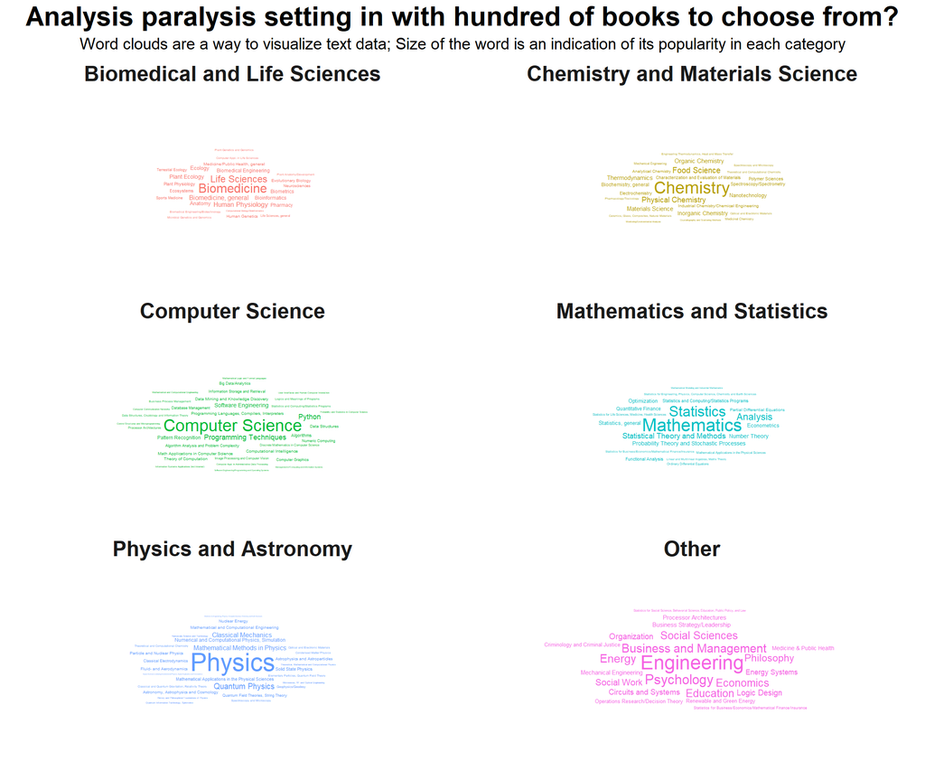

```r
ggplot(wordcloud, aes(
  label = categories,
  size = count,
  colour = popular
)) +
  geom_text_wordcloud_area(rm_outside = TRUE,
                           eccentricity = 1,
                           shape = "pentagon",
  ) +
  scale_size_area(max_size = 20) +
  facet_wrap(. ~ popular, nrow = 3) +
  labs(title = "Analysis paralysis setting in with hundred of books to choose from?", subtitle = "Word clouds are a way to visualize text data; Size of the word is an indication of its popularity in each category") +
  theme(
    plot.title = element_text(face = "bold", size = 25, hjust = 0.5),
    plot.subtitle = element_text(size = 15, hjust = 0.5),
    strip.background = element_blank(),
    strip.text = element_text(face = "bold", size = 20)
  )
```

## 3.3 Potentially esoteric sub-categories within top 6 categories

And just because my wife was curious what the most “obsure” sub-categories were …

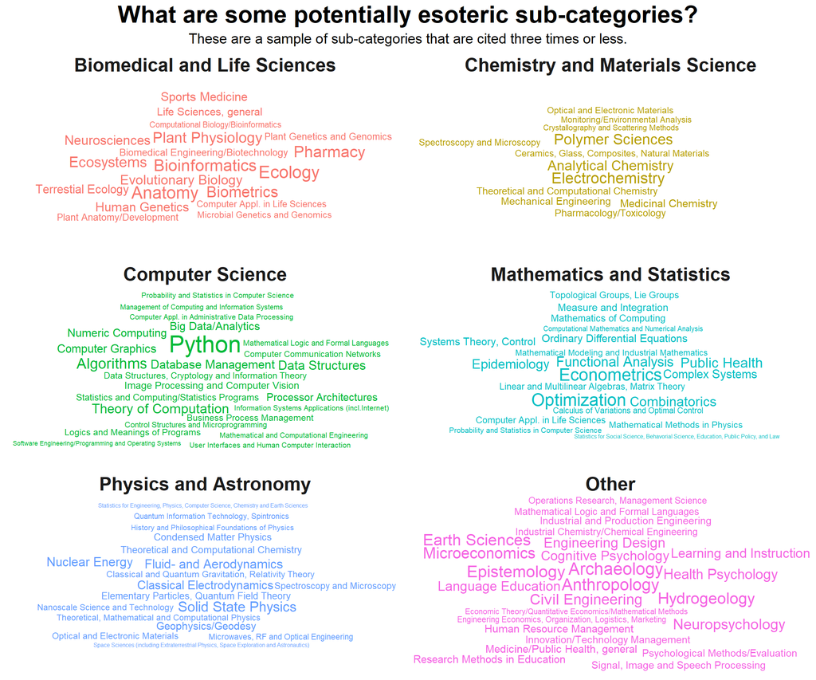

```r
esoteric <- springer_tidy %>%
  mutate(popular = fct_lump_n(english_package_name, 5)) %>%
  group_by(popular, categories) %>%
  summarize(count = n(), .groups = "drop") %>%
  filter(count < 4) %>%
  group_by(popular) %>%
  slice_max(n = 10, order_by = count) %>%
  ungroup()

ggplot(esoteric,
       aes(
         label = categories,
         size = count,
         colour = popular
       )) +
  geom_text_wordcloud_area(
    rm_outside = T,
    eccentricity = 1,
    shape = "pentagon"
  ) +
  scale_size_area(max_size = 20) +
  facet_wrap(. ~ popular, nrow = 3) +
  labs(title = "What are some potentially esoteric sub-categories?", subtitle = "These are a sample of sub-categories that are cited three times or less.") +
  theme(
    plot.title = element_text(face = "bold", size = 25, hjust = 0.5),
    plot.subtitle = element_text(size = 15, hjust = 0.5),
    strip.background = element_blank(),
    strip.text = element_text(face = "bold", size = 20)
  )
```

Once you’ve decided on a category, say Sociology, the following code brings up the book title, author, and the relevant download link

```r
library(kableExtra)

springer_tidy %>%
  filter(str_detect(categories, "Sociology")) %>%
  distinct(book_title, english_package_name, open_url) %>%
  mutate(open_url = cell_spec("SpringerLink", "html", link = open_url)) %>%
  kbl(escape = FALSE) %>%
  kable_styling(bootstrap_options = c("striped", "hover", "condensed"))
```

| book_title | english_package_name | open_url |
| --- | --- | --- |
| Handbook of the Life Course | Humanities, Social Sciences and Law | [SpringerLink](http://link.springer.com/openurl?genre=book&isbn=978-0-306-48247-2) |
| Handbook of Disaster Research | Humanities, Social Sciences and Law | [SpringerLink](http://link.springer.com/openurl?genre=book&isbn=978-0-387-32353-4) |
| Handbook of the Sociology of Gender | Humanities, Social Sciences and Law | [SpringerLink](http://link.springer.com/openurl?genre=book&isbn=978-0-387-36218-2) |
| Handbook of Sociological Theory | Humanities, Social Sciences and Law | [SpringerLink](http://link.springer.com/openurl?genre=book&isbn=978-0-387-36274-8) |
| Grammar for Teachers | Education | [SpringerLink](http://link.springer.com/openurl?genre=book&isbn=978-3-319-33916-0) |
| Business Process Management Cases | Business and Management | [SpringerLink](http://link.springer.com/openurl?genre=book&isbn=978-3-319-58307-5) |
| Teaching Medicine and Medical Ethics Using Popular Culture | Literature, Cultural and Media Studies | [SpringerLink](http://link.springer.com/openurl?genre=book&isbn=978-3-319-65451-5) |
| Business Ethics - A Philosophical and Behavioral Approach | Religion and Philosophy | [SpringerLink](http://link.springer.com/openurl?genre=book&isbn=978-3-319-91575-3) |

I wanted to end the blog post with a showcase of the `DT` package that Antoine Soetewey highlights in his [blog post](https://www.statsandr.com/blog/a-package-to-download-free-springer-books-during-covid-19-quarantine/). Unfortunately, after spending some time experimenting with StackOverflow solutions, I’m still not able to resolve the technical issues preventing me from displaying html widgets on this particular Hugo theme.